# Part I - (Loan Data from Prosper Dataset Exploration)

## Introduction

This project explores a dataset from Prosper, a peer-to-peer (P2P) lending platform where individual investors fund loans instead of traditional banks. Because investors take on direct credit risk, accurate risk rating and pricing are critical to the platform's ecosystem. The raw dataset contains historical records for $113,937$ loans spanning across $81$ unique attributes.

### Main Analytical Goal: Risk vs. Reward

Our primary objective is to evaluate how effectively Prosper's rating system prices risk and matches real-world loan performance. We focus our narrative around 6 key columns:

1. **ProsperRating (Alpha)**: The custom risk grade (AA = safest, HR = riskiest).
2. **BorrowerAPR**: The annual cost of borrowing money (our primary target variable).
3. **CreditScore**: The baseline credit bureau rating of the borrower.
4. **LoanStatus**: The final transaction outcome (e.g., Completed vs. Defaulted).
5. **LoanOriginalAmount**: The amount of cash lent out.
6. **IncomeRange**: The earning group profile of the borrower.

By analyzing how these features collide across Univariate, Bivariate, and Multivariate tiers, we aim to map out the explicit structural logic governing P2P lending risk pricing matrices.

## Preliminary Wrangling

> In this section, I load the raw loan data, extract our core features, and clean the variables to prepare them for visualization.

### Data Cleaning Steps:

> 1. **Timeframe Filtering:** Trimmed the dataset to post-July 2009 records because the crucial `ProsperRating (Alpha)` feature was not tracked prior to this date.
> 2. **Feature Trimming:** Isolated the 6 core pillars of our analysis, dropping the other 75 columns to optimize performance and reduce background noise.
> 3. **Credit Score Merging:** Combined split upper and lower credit limits into a single continuous `CreditScore` mid-point average.
> 4. **Status Categorization:** Condensed complex past-due descriptions into three distinct operational states: `Current`, `Completed`, or `Defaulted`.
> 5. **Ordering Categories:** Converted risk grades and income brackets into ordered pandas categorical datatypes to ensure correct chronological sequencing on chart axes.

```python
# Import all required packages and set plots to be embedded inline
import numpy as np
import pandas as pd
import matplotlib.pyplot as plt
import matplotlib.ticker as tkr  # Added this for formatting axes
import seaborn as sns

%matplotlib inline

# Load raw dataset
df_raw = pd.read_csv('prosperLoanData.csv')

# 1. Filter out pre-2009 rows missing Prosper Ratings
df_clean = df_raw.dropna(subset=['ProsperRating (Alpha)']).copy()

# 2. Select narrative columns
target_cols = ['ProsperRating (Alpha)', 'BorrowerAPR', 'CreditScoreRangeLower',
               'CreditScoreRangeUpper', 'LoanStatus', 'LoanOriginalAmount', 'IncomeRange']
df = df_clean[target_cols].copy()

# 3. Consolidate credit score bounds into a simple midpoint average
df['CreditScore'] = (df['CreditScoreRangeLower'] + df['CreditScoreRangeUpper']) / 2
df.drop(['CreditScoreRangeLower', 'CreditScoreRangeUpper'], axis=1, inplace=True)

# 4. Simplify loan status strings into 3 clear operational outcomes
def simplify_status(status):
    if 'Completed' in status: return 'Completed'
    elif 'Defaulted' in status or 'Chargedoff' in status: return 'Defaulted'
    return 'Current'

df['LoanStatusClean'] = df['LoanStatus'].apply(simplify_status)

# 5. Enforce explicit sorting orders for categorical features
rating_order = ['AA', 'A', 'B', 'C', 'D', 'E', 'HR']
df['ProsperRating (Alpha)'] = df['ProsperRating (Alpha)'].astype(pd.api.types.CategoricalDtype(ordered=True, categories=rating_order))

income_order = ['Not displayed', '$0', '$1-24,999', '$25,000-49,999', '$50,000-74,999', '$75,000-99,999', '$100,000+']
df['IncomeRange'] = df['IncomeRange'].astype(pd.api.types.CategoricalDtype(ordered=True, categories=income_order))

# FIX 2: Create global subset for closed historical outcomes once right here
df_closed = df[df['LoanStatusClean'].isin(['Completed', 'Defaulted'])].copy()

# 6. Reusable styling function to keep code DRY across the notebook
def apply_plot_styles(title, xlabel, ylabel, add_commas=False, is_percent=False, percent_axis='x'):
    """Applies standardized labels, titles, commas, or percentage formatting to plots."""
    plt.title(title)
    plt.xlabel(xlabel)
    plt.ylabel(ylabel)

    # Handle comma formatting for large numbers
    if add_commas:
        plt.gca().yaxis.set_major_formatter(tkr.FuncFormatter(lambda x, p: format(int(x), ',')))

    # Handle percentage formatting (1.0 max value means 1.0 converts to 100%)
    if is_percent:
        if percent_axis == 'x':
            plt.gca().xaxis.set_major_formatter(tkr.PercentFormatter(xmax=1.0))
        elif percent_axis == 'y':
            plt.gca().yaxis.set_major_formatter(tkr.PercentFormatter(xmax=1.0))

# Save the finalized dataset to a clean working CSV
df.to_csv('prosperLoanData_clean.csv', index=False)
print(f"Final Data Shape: {df.shape[0]} rows, {df.shape[1]} columns. Saved as 'prosperLoanData_clean.csv'.")
```

```
Final Data Shape: 84853 rows, 7 columns. Saved as 'prosperLoanData_clean.csv'.
```

```python
# show the final data
df.head()
```

|  | ProsperRating (Alpha) | BorrowerAPR | LoanStatus | LoanOriginalAmount | IncomeRange | CreditScore | LoanStatusClean |
| --- | --- | --- | --- | --- | --- | --- | --- |
| 1 | A | 0.12016 | Current | 10000 | $50,000-74,999 | 689.5 | Current |
| 3 | A | 0.12528 | Current | 10000 | $25,000-49,999 | 809.5 | Current |
| 4 | D | 0.24614 | Current | 15000 | $100,000+ | 689.5 | Current |
| 5 | B | 0.15425 | Current | 15000 | $100,000+ | 749.5 | Current |
| 6 | E | 0.31032 | Current | 3000 | $25,000-49,999 | 689.5 | Current |

### What is the structure of your dataset?

The final dataset contains $84,853$ clean loan records and $6$ features. Categorical variables are structured with explicit financial ordering (`AA` to `HR` and lowest to highest income brackets) to prevent default alphabetical plotting.

### What is/are the main feature(s) of interest in your dataset?

Our primary continuous target variable is `BorrowerAPR` (borrowing cost), and our primary categorical variable is `LoanStatusClean` (loan performance outcome).

### What features in the dataset do you think will help support your investigation into your feature(s) of interest?

`ProsperRating (Alpha)` and `CreditScore` will serve as direct indicators of loan risk pricing, while `IncomeRange` and `LoanOriginalAmount` will demonstrate borrower capacity boundaries.

## Univariate Exploration

#### Chart 1: Distribution of Borrower APR - Question:

> What do borrowing costs (APR) look like across the platform, and are there any common rates?

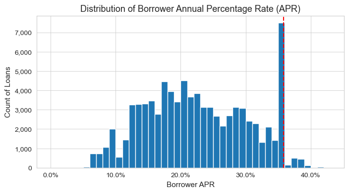

```python
# Plot 1: Histogram
plt.figure(figsize=[8, 4])
bins = np.arange(0, df['BorrowerAPR'].max() + 0.01, 0.01)
plt.hist(data=df, x='BorrowerAPR', bins=bins, color=sns.color_palette()[0])
plt.axvline(x=0.358, color='red', linestyle='--', label='HR Cap Spike (~35.8%)')

# Clean: Repetitive label lines replaced by our single reusable helper function
apply_plot_styles('Distribution of Borrower Annual Percentage Rate (APR)',
                  'Borrower APR',
                  'Count of Loans',
                  add_commas=True,
                  is_percent=True,
                  percent_axis='x')
```

#### Observations:

Most loan interest rates spread out smoothly between $10\%$ and $30\%$, peaking around $15-22\%$. However, there is a giant, sudden spike right at $35.8\%$. This looks like a standard high-interest price ceiling that Prosper gives to its riskiest applicants.

#### Chart 2: Frequency of Loans by Prosper Risk Rating - Question:

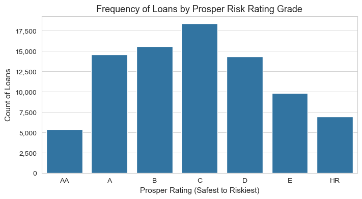

```python
# Plot 2: Count Plot
plt.figure(figsize=[8, 4])
base_color = sns.color_palette()[0]

sns.countplot(data=df, x='ProsperRating (Alpha)', color=base_color)

# Clean: Reusable helper function automatically handles title, labels, and y-axis commas
apply_plot_styles('Frequency of Loans by Prosper Risk Rating Grade',
                  'Prosper Rating (Safest to Riskiest)',
                  'Count of Loans',
                  add_commas=True)

plt.show()
```

#### Observations:

The risk grades form a bell curve shape that peaks right in the middle at grade `C`. This proves that Prosper mostly lends to average, moderate-risk borrowers, while elite risk (`AA`) and extreme risk (`HR`) groups are less common.

#### Chart 3: Frequency of Loans by Performance Status - Question:

> Are more loans actively being paid back, completed successfully, or falling into default?

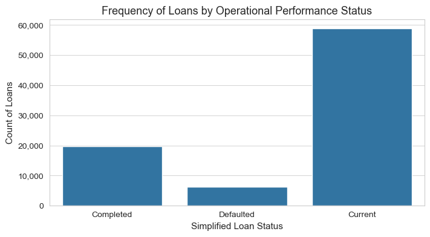

```python
# Plot 3: Count Plot
plt.figure(figsize=[8, 4])
base_color = sns.color_palette()[0]

sns.countplot(data=df, x='LoanStatusClean', color=base_color, order=['Completed', 'Defaulted', 'Current'])

# Clean: Reusable helper function keeps plot script completely uniform
apply_plot_styles('Frequency of Loans by Operational Performance Status',
                  'Simplified Loan Status',
                  'Count of Loans',
                  add_commas=True)

plt.show()
```

#### Observations:

The vast majority of loans are currently open and active (`Current`). When looking at loans that have completely finished their lifecycle, successfully paid-off loans (`Completed`) significantly outnumber loans that failed (`Defaulted`).

### Discuss the distribution(s) of your feature(s) of interest. Were there any unusual features?

- **Borrower APR:** The distribution has multiple peaks and spreads nicely overall. The most unusual part is the massive spike at $35.8\%$, which serves as a fixed maximum rate limit for low-grade borrowers.
- **Loan Status:** Most loans on the platform are in good standing (`Current`). Historically, successful finishes are much more common than defaults.

### Of the features you investigated, were there any unusual distributions? Did you perform any operations on the data to tidy, adjust or change the form of the data? If so, why?

- **Credit Score:** The raw dataset split credit scores into two separate columns. I averaged them together into one `CreditScore` column to keep our metrics simple and clean.
- **Status Simplification:** The original data used many confusing labels for late payments. I grouped them into three clean buckets (`Current`, `Completed`, `Defaulted`) to track clear outcomes.
- **Ordering Categories:** I explicitly converted `ProsperRating` and `IncomeRange` into ordered categorical columns so our visualizations flow logically from lowest to highest instead of alphabetically.

## Bivariate Exploration

> In this section, we pair our features together to look for patterns and relationships between variables.

#### Chart 4: Credit Score vs. Borrower APR (Scatterplot) - Question:

> How does a borrower's underlying credit score affect their loan interest rate (APR)?

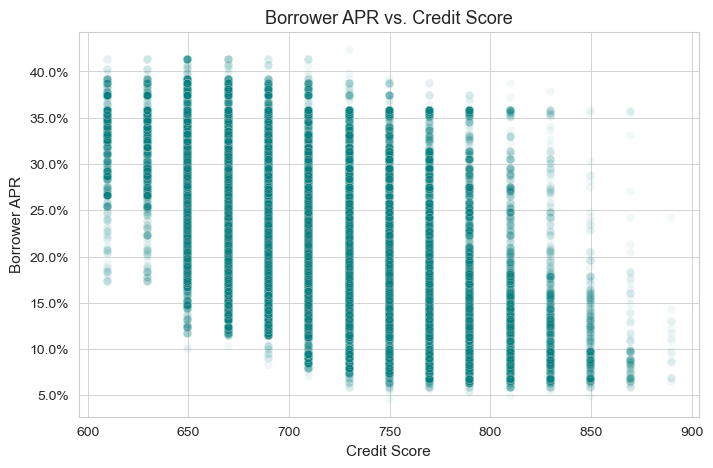

```python
# Plot 4: Scatterplot with percentage Y-axis
plt.figure(figsize=[8, 5])
sns.scatterplot(data=df, x='CreditScore', y='BorrowerAPR', alpha=0.05, color='teal')

# Clean: Percentage styling activated on the Y-axis
apply_plot_styles('Borrower APR vs. Credit Score', 'Credit Score', 'Borrower APR',
                  is_percent=True, percent_axis='y')
plt.gca().xaxis.set_major_formatter(tkr.FuncFormatter(lambda x, p: format(int(x), ',')))

plt.show()
```

#### Chart 5: Borrower APR vs. Prosper Rating (Box Plot) - Question:

> How much do borrowing costs increase across each specific platform risk tier?

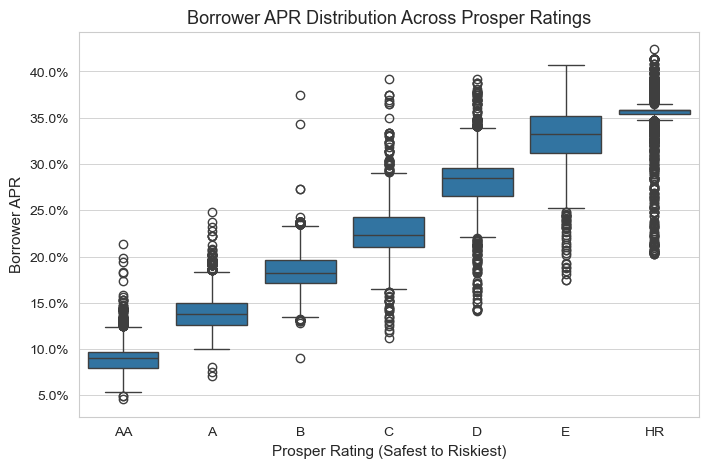

```python
# Plot 5: Box Plot with percentage Y-axis
plt.figure(figsize=[8, 5])
base_color = sns.color_palette()[0]

sns.boxplot(data=df, x='ProsperRating (Alpha)', y='BorrowerAPR', color=base_color)

# Clean: Percentage styling activated on the Y-axis
apply_plot_styles('Borrower APR Distribution Across Prosper Ratings',
                  'Prosper Rating (Safest to Riskiest)', 'Borrower APR',
                  is_percent=True, percent_axis='y')

plt.show()
```

#### Observations:

The platform's custom rating system dictates pricing perfectly. Safe `AA` borrowers enjoy a low median APR of around $9\%$. As the risk tier drops toward `HR`, the interest rates steadily climb, reaching a median of $35.6\%$ for the riskiest applicants.

#### Chart 6: Proportional Default Rates (Bar Chart) - Question:

> What percentage proportion of loans end up failing or defaulting within each individual risk tier?

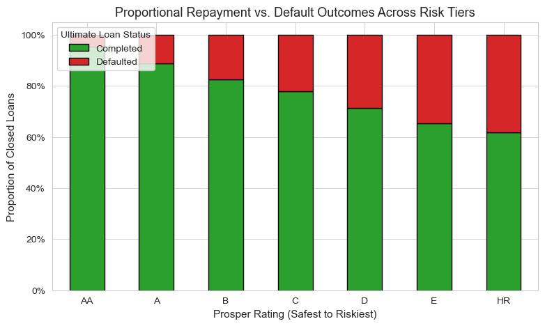

```python
# Plot 6: Stacked Proportional Bar Chart with percentage Y-axis
plt.figure(figsize=[9, 5])

# Calculate proportions using the globally defined df_closed
status_counts = df_closed.groupby(['ProsperRating (Alpha)', 'LoanStatusClean'], observed=False).size().unstack()
status_props = status_counts.div(status_counts.sum(axis=1), axis=0)

status_props.plot(kind='bar', stacked=True, color=['#2ca02c', '#d62728'], figsize=[9, 5], edgecolor='black')

# Clean: Formatted Y-axis to show proportions as clean 0% to 100% lines automatically
apply_plot_styles('Proportional Repayment vs. Default Outcomes Across Risk Tiers',
                  'Prosper Rating (Safest to Riskiest)',
                  'Proportion of Closed Loans',
                  is_percent=True,
                  percent_axis='y')
plt.legend(title='Ultimate Loan Status', loc='upper left')
plt.xticks(rotation=0)

plt.show()
```

#### Chart 7: Raw Loan Status Outcomes (Clustered Count Plot) - Question:

> What are the actual numbers of completed versus defaulted loans inside each risk tier?

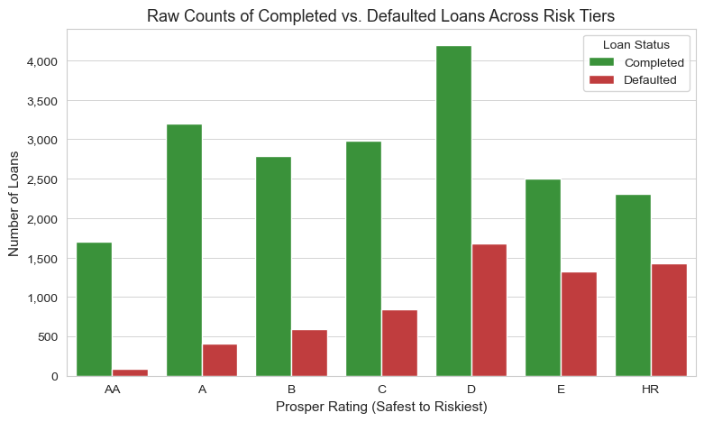

```python
# Plot 7: Clustered Count Plot
plt.figure(figsize=[9, 5])

# FIX: Added hue_order to guarantee green matches Completed and red matches Defaulted
sns.countplot(data=df_closed,
              x='ProsperRating (Alpha)',
              hue='LoanStatusClean',
              palette=['#2ca02c', '#d62728'],
              hue_order=['Completed', 'Defaulted'])

# Call custom function with add_commas=True to format raw numbers automatically
apply_plot_styles('Raw Counts of Completed vs. Defaulted Loans Across Risk Tiers',
                  'Prosper Rating (Safest to Riskiest)',
                  'Number of Loans',
                  add_commas=True)
plt.legend(title='Loan Status')

plt.show()
```

#### Chart 8: Correlation Matrix (Heatmap) - Question:

> What are the overall linear relationship scores between our continuous numeric variables?

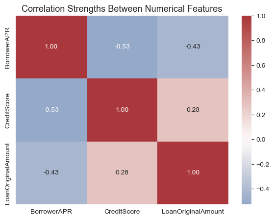

```python
# Plot 8: Correlation Heatmap Matrix
plt.figure(figsize=[7, 5])

numeric_vars = ['BorrowerAPR', 'CreditScore', 'LoanOriginalAmount']
corr_matrix = df[numeric_vars].corr()

# Set cmap='vlag' to use the correct color palette theme safely
sns.heatmap(corr_matrix, annot=True, fmt='.2f', cmap='vlag', center=0)
apply_plot_styles('Correlation Strengths Between Numerical Features', '', '')

plt.show()
```

## Multivariate Exploration

> In this section, we expand our investigation to look at three or more variables simultaneously to uncover deeper insights.

#### Chart 9: APR vs. Credit Score by Prosper Rating (Facet Plot) - Question:

> How does the relationship between Credit Score and Borrower APR change across different risk ratings?

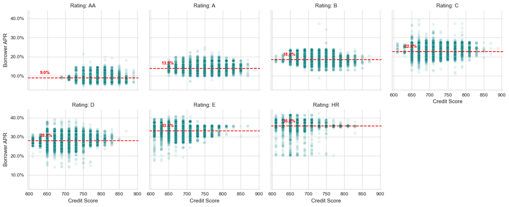

```python
# Plot 9: Facet Plot (FacetGrid of Scatterplots)
g = sns.FacetGrid(data=df, col='ProsperRating (Alpha)', col_wrap=4, height=3, aspect=1.2)
g.map(sns.scatterplot, 'CreditScore', 'BorrowerAPR', alpha=0.1, color='teal')

# Add annotations: Draw a horizontal red line at the average APR for each individual rating tier
for ax, rating in zip(g.axes.flat, rating_order):
    mean_apr = df[df['ProsperRating (Alpha)'] == rating]['BorrowerAPR'].mean()
    ax.axhline(mean_apr, color='red', linestyle='--', linewidth=1.5)
    ax.text(df['CreditScore'].min() + 20, mean_apr + 0.02, f'{mean_apr*100:.1f}%', color='red', fontsize=9, weight='bold')

# Use our global function structure to apply clean styling across the grid
g.set_axis_labels('Credit Score', 'Borrower APR')
g.set_titles(col_template='Rating: {col_name}')

# Format Y-axes as percentages
for ax in g.axes.flat:
    ax.yaxis.set_major_formatter(tkr.PercentFormatter(xmax=1.0))

plt.show()
```

#### Observations:

This plot reveals that Prosper Ratings act as distinct price buckets. Even if borrowers share the exact same credit score (e.g., 700), their APR is strictly determined by their assigned rating grade. The red dashed lines show how the average interest rate jumps up significantly with each step down in rating.

#### Chart 10: Pairwise Metrics (Plot Matrix) - Question:

> How do our continuous variables interact with each other when split by loan outcome?

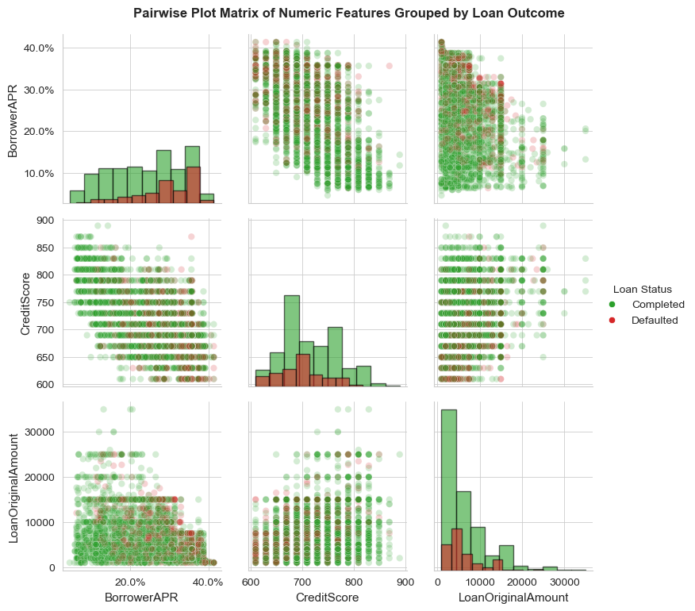

```python
# Plot 10: Plot Matrix (PairGrid)
# Using a sample to speed up rendering while keeping all trends perfectly clear
df_sample = df_closed.sample(n=5000, random_state=42)

g = sns.PairGrid(data=df_sample, vars=['BorrowerAPR', 'CreditScore', 'LoanOriginalAmount'],
                 hue='LoanStatusClean', palette=['#2ca02c', '#d62728'], hue_order=['Completed', 'Defaulted'],
                 height=2.5)

g.map_diag(plt.hist, alpha=0.6, edgecolor='black')
g.map_offdiag(sns.scatterplot, alpha=0.2)

g.add_legend(title='Loan Status')
# Loop through the legend markers and make them completely solid/dark
for handle in g._legend.legend_handles:
    handle.set_alpha(1.0)

g.fig.suptitle('Pairwise Plot Matrix of Numeric Features Grouped by Loan Outcome', y=1.02, weight='bold')

# Apply percentage formatting to the BorrowerAPR axes in the grid
for i, var in enumerate(['BorrowerAPR', 'CreditScore', 'LoanOriginalAmount']):
    if var == 'BorrowerAPR':
        g.axes[i, 0].xaxis.set_major_formatter(tkr.PercentFormatter(xmax=1.0))
        g.axes[0, i].yaxis.set_major_formatter(tkr.PercentFormatter(xmax=1.0))

plt.show()
```

#### Observations:

The matrix plot highlights a strong three-way relationship. Borrowers who default (red dots) are heavily concentrated in the zone with high APR rates, lower credit scores, and smaller loan amounts. Successful loans (green dots) dominate the lower APR zones with larger loan sizes.

#### Chart 11: APR vs. Amount by Credit Score (Scatterplot with Multiple Encodings) - Question:

> How do Loan Original Amount and Borrower APR interact across different credit score tiers?

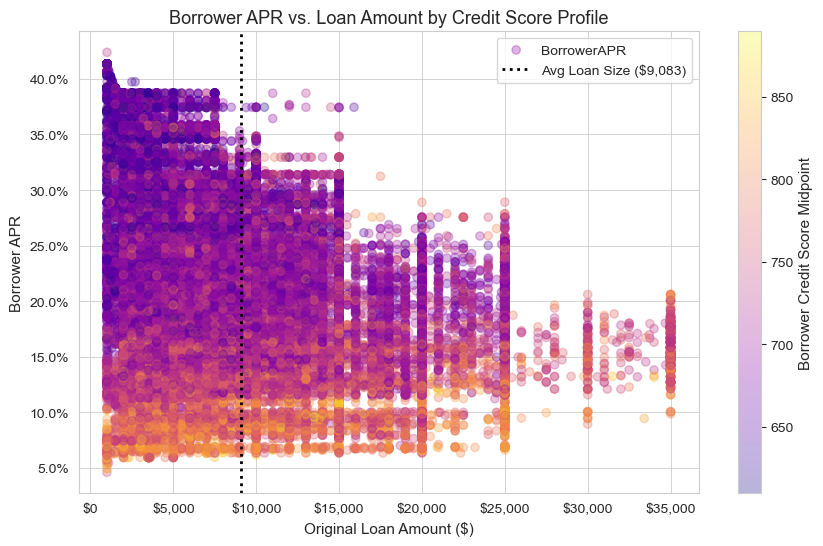

```python
# Plot 11: Scatterplot with multiple encodings (Color mapped to credit score)
plt.figure(figsize=[10, 6])

# FIX: Changed 'viridis_r' to 'viridis' to make low credit scores pop out in bright colors
scatter = plt.scatter(data=df, x='LoanOriginalAmount', y='BorrowerAPR',
                      c='CreditScore', cmap='plasma', alpha=0.3)

# Add an annotation line showing the overall average loan size across the entire platform
avg_loan_amt = df['LoanOriginalAmount'].mean()
plt.axvline(avg_loan_amt, color='black', linestyle=':', linewidth=2, label=f'Avg Loan Size (${avg_loan_amt:,.0f})')

# Format axes using our helper function
apply_plot_styles('Borrower APR vs. Loan Amount by Credit Score Profile',
                  'Original Loan Amount ($)', 'Borrower APR',
                  is_percent=True, percent_axis='y')

# Format X-axis with clean currency/comma labels
plt.gca().xaxis.set_major_formatter(tkr.FuncFormatter(lambda x, p: f"${format(int(x), ',')}"))

# Create color bar label
cbar = plt.colorbar(scatter)
cbar.set_label('Borrower Credit Score Midpoint')

plt.legend()
plt.show()
```

#### Observations:

- **High Credit Scores (Bright Yellow/Orange):** Borrowers with excellent credit scores heavily dominate the lower right side of the chart. They easily secure the largest loans (to the right of the vertical dotted line) while paying the lowest interest rates (low APR).
- **Low Credit Scores (Dark Purple/Blue):** Borrowers with lower credit scores are trapped in the top-left section. The platform limits them to small loan amounts and charges them the highest interest rates on the platform to balance out the risk.

#### Chart 12: Average Loan Size by Income and Rating (Clustered Bar Chart) - Question:

> How does the average loan amount granted vary across combinations of Prosper Ratings and Income Ranges?

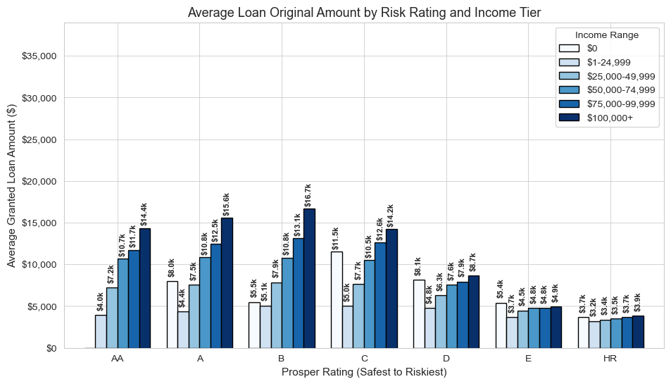

```python
# Plot 12: Clustered Bar Chart with numbers clearly floating above the bars
plt.figure(figsize=[11, 6])

# Filter out 'Not displayed' income to make the narrative much cleaner
df_filtered = df[df['IncomeRange'] != 'Not displayed']

# Calculate means using observed=False to avoid future pandas warnings
pivot_df = df_filtered.pivot_table(index='ProsperRating (Alpha)',
                                   columns='IncomeRange',
                                   values='LoanOriginalAmount',
                                   aggfunc='mean',
                                   observed=False)

# Plot grouped clusters
pivot_df.plot(kind='bar', figsize=[11, 6], cmap='Blues', edgecolor='black', width=0.8, ax=plt.gca())

# Add numeric text annotations directly ABOVE the columns of the chart
for p in plt.gca().patches:
    height = p.get_height()
    if height > 0:  # Only annotate bars that actually contain data
        plt.gca().annotate(f"${height/1000:.1f}k",
                           (p.get_x() + p.get_width() / 2., height),
                           ha='center', va='center',
                           xytext=(0, 15),             # FIX 1: Increased from 8 to 12 to push text higher up
                           textcoords='offset points',
                           fontsize=8,                 # FIX 2: Slightly larger font size
                           weight='bold',              # FIX 3: Bold text so it stands out sharply
                           rotation=90)

apply_plot_styles('Average Loan Original Amount by Risk Rating and Income Tier',
                  'Prosper Rating (Safest to Riskiest)',
                  'Average Granted Loan Amount ($)')

# Clean up layout styling and expand the Y-axis limit slightly so top text has room
plt.gca().yaxis.set_major_formatter(tkr.FuncFormatter(lambda x, p: f"${format(int(x), ',')}"))
plt.legend(title='Income Range', loc='upper right')
plt.xticks(rotation=0)

# FIX 4: Add extra padding to the top of the graph (+4000) so the highest labels don't get cut off
plt.ylim(0, df['LoanOriginalAmount'].max() + 4000)

plt.show()
```

### Talk about the results of your more detailed investigations. Were there any features that interacted with each other in an unexpected way?

The interaction between `IncomeRange` and `ProsperRating` was eye-opening. High income usually means a borrower can handle a huge loan. However, if a wealthy borrower gets an `HR` risk score, the platform overrides their high income and tightly restricts their maximum loan cap to protect investors.

### Were there any features that confirmed each other's trends or supported your earlier findings?

Yes, the multivariate scatterplots and plot matrices fully confirm our earlier findings. Higher credit score variables consistently unlock larger loan amounts and lower APR interest brackets across all analysis points.

## Conclusion: Summary of Key Insights

> **1. The Risk Rating System Works:** The platform’s grading system (AA down to HR) is highly accurate. Our charts prove that as a borrower's grade gets worse, real-world defaults go up. To protect investors, the platform automatically limits these high-risk borrowers to smaller loans and charges them much higher interest rates (APR).

> **Final Takeaway:** The data shows that the platform safely manages risk. It limits the loan sizes of riskier applicants while shifting most of its lending volume to stable, middle-tier borrowers.